# HW2

Emily P. Piché

1/25/2019

#### Homework 2

##### Introduction

Health outcomes between rural and urban residents often differ in developing nations due to difference socioeconomic status. This difference in socioeconomic status can have drastic effects on both lifestyle and access to healthcare. In this study, two groups of Guatemalans were studied to determine if total serum cholesterol levels were associated with urban or rural resident status. Here, 94 native Guatemalans volunteered to have their blood serum cholesterol levels examined. High cholesterol levels are a risk factor for several types of cardiovascular disease, and can be treated with both perscription treatment (statins, such as the brand name drug Lipitor) and through change in diet.

##### Methods

Individuals from both urban and rural areas elected to have their total serum cholesteral levels tested (45 urban, 49 rural residents). The mean of these two groups were then compared using a t-test with a significance level of .05. As the hypothesis was non-directional, a two tailed t-test was conducted.

##### Results

The results of this test indicate that there is indeed a difference in cholesterol levels between the urban and rural Guatemalens, with a significance level of .05 (t = 8.08, p < .001 ). This test was conducted using the tadaatoolbox package in R.

##### Discussion

Although the t-test indicated that there is a difference in the means of the two groups, the method of data collection should be considered when interpreting these results. It should be noted that this test can only determine difference between the sample groups rather than the population at large. This is due to the individuals in this study volunteering themselves as participants, rather than examinging serum cholesterol levels of individuals randomly selected from each of the two populations. As a result, uncontrolled factors may have influenced the results of the study. For example, if individuals living in a rural area have less access to health-care, those with existing conditions may have been more likely to volunteer for the study, leading to a smaller difference in means than if the study participants had been randomly selected. Despite this, the large difference in serum levels indicates that future testing is needed to understand the difference in health outcomes between the two populations more completely.

##### Appendix - Figures

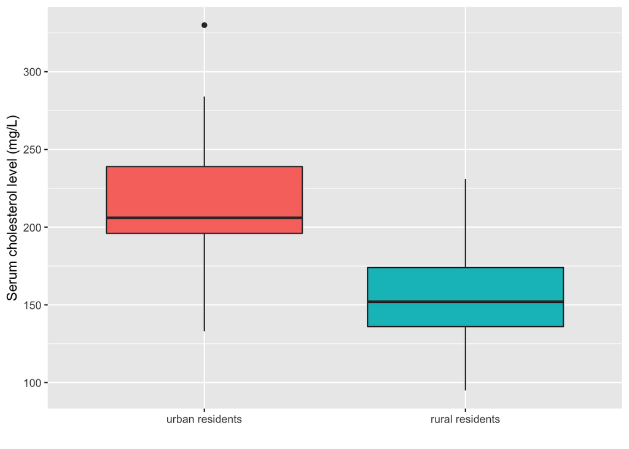

Figure 1. Blood serum cholesterol levels of urban and rural Guatemalans